# A4_Nguyen_Vu

Vu Nguyen

2024-06-12

```r
# Package loading. Install the following packages before running this chunk or knitting this program.
library(C50)
library(knitr)
library(matrixStats)
library(e1071)
library(caret)
```

```r
library(rminer)
library(tictoc)
library(ggplot2)
library(dplyr)
library(rmarkdown)
library(psych)
library(rpart)
library(RWeka)
library(rpart.plot)
library(rJava)
```

# 1 Task I (95%)

## 1.1 Part 1. Code chunk 1 (20%)- Set up, data import, data exploration, data partitioning, and inspection code

### 1.1.1 A. Package loading, and data import

#### 1.1.1.1 Set Directory

```r
tic()
# Set the working directory to the directory where your rmarkdown program file resides in rstudio using getwd() and setwd()
mydir_wd <- getwd()
setwd(mydir_wd)

# Import a csv file
VideoGameSales <- read.csv(file = "NA_sales_filtered.csv", stringsAsFactors = FALSE)
```

#### 1.1.1.2 Load character String, Summary, Structure before Factor

```r
# examine data before data factorization
str(VideoGameSales) #structure
```

```
## 'data.frame':    6345 obs. of  9 variables:
##  $ Name        : chr  "Final Fantasy VII" "Final Fantasy X" "The Sims 3" "Final Fantasy VIII" ...
##  $ Platform    : chr  "PS" "PS2" "PC" "PS" ...
##  $ Genre       : chr  "Role-Playing" "Role-Playing" "Simulation" "Role-Playing" ...
##  $ Rating      : chr  "T" "T" "T" "T" ...
##  $ Critic_Score: int  92 92 86 90 96 88 92 96 93 87 ...
##  $ Critic_Count: int  20 53 75 24 15 29 97 105 57 22 ...
##  $ User_Score  : int  91 86 75 85 90 84 82 87 72 80 ...
##  $ User_Count  : int  1282 1056 886 644 367 135 3712 5187 2182 78 ...
##  $ NA_Sales    : num  3.01 2.91 0.99 2.28 3.27 2.93 2.77 3.27 0.08 3.11 ...
```

```r
summary(VideoGameSales) #summary
```

```
##      Name             Platform            Genre              Rating
##  Length:6345        Length:6345        Length:6345        Length:6345
##  Class :character   Class :character   Class :character   Class :character
##  Mode  :character   Mode  :character   Mode  :character   Mode  :character
##
##
##
##   Critic_Score    Critic_Count      User_Score      User_Count
##  Min.   :13.00   Min.   :  3.00   Min.   : 5.00   Min.   :    4.0
##  1st Qu.:61.00   1st Qu.: 14.00   1st Qu.:64.00   1st Qu.:   10.0
##  Median :72.00   Median : 25.00   Median :74.00   Median :   24.0
##  Mean   :69.82   Mean   : 28.97   Mean   :70.77   Mean   :  152.7
##  3rd Qu.:80.00   3rd Qu.: 40.00   3rd Qu.:81.00   3rd Qu.:   77.0
##  Max.   :98.00   Max.   :113.00   Max.   :95.00   Max.   :10665.0
##     NA_Sales
##  Min.   :0.0100
##  1st Qu.:0.0800
##  Median :0.1700
##  Mean   :0.3542
##  3rd Qu.:0.4100
##  Max.   :3.4900
```

#### 1.1.1.3 Other than the Name, transform all other non-numeric fields to be factor variables.

```r
#?factor
#?mutate_if
#?across
#?where
#?ifelse
#?name()
VideoGameSales <- VideoGameSales %>% mutate_if(~ is.character(.) && !identical(.,VideoGameSales$Name), as.factor) #factor all except Name
```

### 1.1.2 B. Use pairs.panels to show distributions and correlations of all of the numeric variables.

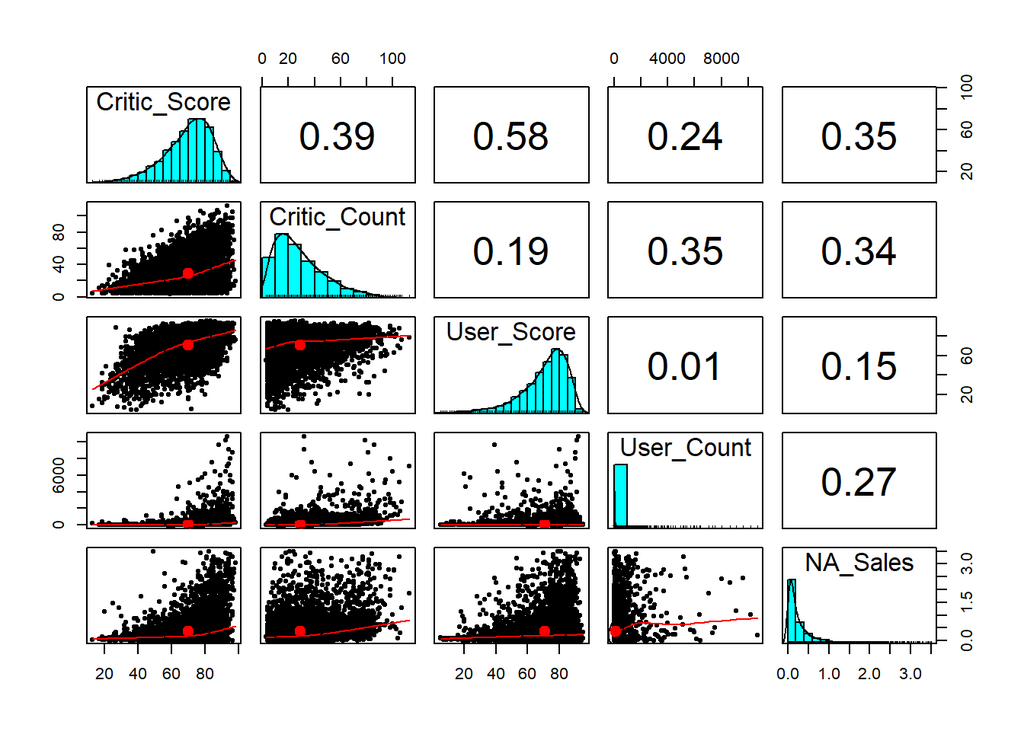

```r
#?pairs.panels
VideoGameSales %>% select(where(is.numeric)) %>% pairs.panels()
```

### C. Remove the Name variable from the data frame. All subsequent models should have this column excluded. Build a linear regression model. Show the summary of the model to understand the significance and coefficients of the predictors in the model and the overall model fit. Note that the purpose of this task is not to build a predictive model. Rather, it is often a good idea to explore a data set with white-box models like linear regression (for numeric target variable) or decision tree (for factor target variable).

```r
#remove the Name Column
VideoGameSales <- VideoGameSales %>% select(-Name)
```

```r
#regression model
LinearModel <- lm(NA_Sales ~ ., data = VideoGameSales)
LinearModel
```

```
##
## Call:
## lm(formula = NA_Sales ~ ., data = VideoGameSales)
##
## Coefficients:
##       (Intercept)         PlatformDS        PlatformGBA         PlatformGC
##        -0.4045270          0.1546544          0.1705088          0.0891789
##        PlatformPC         PlatformPS        PlatformPS2        PlatformPS3
##        -0.3053702          0.4074675          0.1954121          0.0971781
##       PlatformPS4        PlatformPSP        PlatformPSV        PlatformWii
##        -0.0737898          0.0400740         -0.1176330          0.2400632
##      PlatformWiiU       PlatformX360         PlatformXB       PlatformXOne
##         0.0286638          0.1387340          0.0212235          0.1621404
##    GenreAdventure      GenreFighting          GenreMisc      GenrePlatform
##        -0.1253577          0.0030300          0.0837469         -0.0313517
##       GenrePuzzle        GenreRacing  GenreRole-Playing       GenreShooter
##        -0.1314889         -0.0413035         -0.1029503          0.0029083
##   GenreSimulation        GenreSports      GenreStrategy         RatingE10+
##         0.0586782         -0.0238707         -0.1726147         -0.0578194
##           RatingM      Ratingmissing            RatingT       Critic_Score
##        -0.1121169         -0.2243593         -0.0932792          0.0104880
##      Critic_Count         User_Score         User_Count
##         0.0061220         -0.0028238          0.0002027
```

```r
summary(LinearModel)
```

```
##
## Call:
## lm(formula = NA_Sales ~ ., data = VideoGameSales)
##
## Residuals:
##     Min      1Q  Median      3Q     Max
## -1.9381 -0.2315 -0.0818  0.0978  3.1769
##
## Coefficients:
##                     Estimate Std. Error t value Pr(>|t|)
## (Intercept)       -4.045e-01  4.796e-02  -8.435  < 2e-16 ***
## PlatformDS         1.547e-01  4.088e-02   3.783 0.000156 ***
## PlatformGBA        1.705e-01  4.573e-02   3.729 0.000194 ***
## PlatformGC         8.918e-02  4.276e-02   2.085 0.037071 *
## PlatformPC        -3.054e-01  4.554e-02  -6.706 2.17e-11 ***
## PlatformPS         4.075e-01  5.080e-02   8.020 1.25e-15 ***
## PlatformPS2        1.954e-01  3.851e-02   5.074 4.00e-07 ***
## PlatformPS3        9.718e-02  3.929e-02   2.473 0.013422 *
## PlatformPS4       -7.379e-02  4.670e-02  -1.580 0.114165
## PlatformPSP        4.007e-02  4.201e-02   0.954 0.340130
## PlatformPSV       -1.176e-01  5.741e-02  -2.049 0.040509 *
## PlatformWii        2.401e-01  4.070e-02   5.898 3.87e-09 ***
## PlatformWiiU       2.866e-02  5.892e-02   0.487 0.626616
## PlatformX360       1.387e-01  3.906e-02   3.551 0.000386 ***
## PlatformXB         2.122e-02  4.060e-02   0.523 0.601157
## PlatformXOne       1.621e-01  4.988e-02   3.251 0.001157 **
## GenreAdventure    -1.254e-01  3.082e-02  -4.068 4.81e-05 ***
## GenreFighting      3.030e-03  2.539e-02   0.119 0.905002
## GenreMisc          8.375e-02  2.503e-02   3.346 0.000823 ***
## GenrePlatform     -3.135e-02  2.551e-02  -1.229 0.219107
## GenrePuzzle       -1.315e-01  4.298e-02  -3.059 0.002230 **
## GenreRacing       -4.130e-02  2.282e-02  -1.810 0.070341 .
## GenreRole-Playing -1.030e-01  2.038e-02  -5.052 4.50e-07 ***
## GenreShooter       2.908e-03  1.894e-02   0.154 0.877966
## GenreSimulation    5.868e-02  2.951e-02   1.988 0.046825 *
## GenreSports       -2.387e-02  2.134e-02  -1.118 0.263445
## GenreStrategy     -1.726e-01  3.297e-02  -5.235 1.71e-07 ***
## RatingE10+        -5.782e-02  1.888e-02  -3.062 0.002205 **
## RatingM           -1.121e-01  2.107e-02  -5.322 1.06e-07 ***
## Ratingmissing     -2.244e-01  8.975e-02  -2.500 0.012451 *
## RatingT           -9.328e-02  1.679e-02  -5.557 2.86e-08 ***
## Critic_Score       1.049e-02  5.435e-04  19.298  < 2e-16 ***
## Critic_Count       6.122e-03  3.687e-04  16.605  < 2e-16 ***
## User_Score        -2.824e-03  4.930e-04  -5.729 1.06e-08 ***
## User_Count         2.027e-04  1.172e-05  17.287  < 2e-16 ***
## ---
## Signif. codes:  0 '***' 0.001 '**' 0.01 '*' 0.05 '.' 0.1 ' ' 1
##
## Residual standard error: 0.421 on 6310 degrees of freedom
## Multiple R-squared:  0.2787, Adjusted R-squared:  0.2749
## F-statistic: 71.72 on 34 and 6310 DF,  p-value: < 2.2e-16
```

### 1.1.3 D. Partition the dataset for simple hold-out evaluation – 70% for training and the other 30% for testing.

```r
set.seed(100)
index_numbers_split <- createDataPartition(VideoGameSales$NA_Sales,p=.7,list = FALSE)
train_target <- VideoGameSales[index_numbers_split,8]
test_target <- VideoGameSales[-index_numbers_split,8]
train_set <- VideoGameSales[index_numbers_split,-8] #partition the 70% to the train set
test_set <- VideoGameSales[-index_numbers_split,-8] #simply get the rest of the set and make it test set (30% from the 100%)
```

### 1.1.4 E. Show the overall summaries of training and testing sets.

```r
summary(train_set)
```

```
##     Platform             Genre          Rating      Critic_Score
##  PS2    : 793   Action      :1076   E      :1404   Min.   :19.00
##  X360   : 609   Sports      : 666   E10+   : 597   1st Qu.:61.00
##  PS3    : 512   Shooter     : 549   M      : 908   Median :72.00
##  XB     : 423   Role-Playing: 447   missing:  13   Mean   :69.87
##  Wii    : 325   Racing      : 368   T      :1520   3rd Qu.:80.00
##  DS     : 312   Platform    : 283                  Max.   :97.00
##  (Other):1468   (Other)     :1053
##   Critic_Count      User_Score      User_Count
##  Min.   :  3.00   Min.   : 5.00   Min.   :    4.0
##  1st Qu.: 14.00   1st Qu.:63.00   1st Qu.:   10.0
##  Median : 25.00   Median :74.00   Median :   24.0
##  Mean   : 29.06   Mean   :70.74   Mean   :  149.5
##  3rd Qu.: 40.00   3rd Qu.:81.00   3rd Qu.:   77.0
##  Max.   :107.00   Max.   :95.00   Max.   :10179.0
##
```

```r
summary(test_set)
```

```
##     Platform            Genre         Rating     Critic_Score
##  PS2    :342   Action      :473   E      :564   Min.   :13.00
##  X360   :239   Sports      :255   E10+   :280   1st Qu.:61.00
##  PS3    :237   Shooter     :249   M      :387   Median :72.00
##  XB     :155   Role-Playing:196   missing: 10   Mean   :69.69
##  Wii    :150   Racing      :169   T      :662   3rd Qu.:80.00
##  DS     :145   Misc        :120                 Max.   :98.00
##  (Other):635   (Other)     :441
##   Critic_Count      User_Score      User_Count
##  Min.   :  4.00   Min.   : 8.00   Min.   :    4.0
##  1st Qu.: 14.00   1st Qu.:64.00   1st Qu.:   10.0
##  Median : 24.00   Median :74.00   Median :   24.0
##  Mean   : 28.74   Mean   :70.83   Mean   :  160.2
##  3rd Qu.: 39.00   3rd Qu.:81.00   3rd Qu.:   76.5
##  Max.   :113.00   Max.   :94.00   Max.   :10665.0
##
```

## 1.2 Part 2. Code chunk 2 (20%)– lm, rpart and M5P model training and testing

### 1.2.1 A. Train three models using lm, rpart, and M5P on the training set (built in 1. D). Use the default settings of these methods throughout this assignment.

```r
#linear regression model
vgs_lm_train_model <- lm(train_target~., data = train_set)
vgs_lm_train_model
```

```
##
## Call:
## lm(formula = train_target ~ ., data = train_set)
##
## Coefficients:
##       (Intercept)         PlatformDS        PlatformGBA         PlatformGC
##        -0.3761735          0.1666690          0.1640525          0.0832131
##        PlatformPC         PlatformPS        PlatformPS2        PlatformPS3
##        -0.3178635          0.4070517          0.1926390          0.0963428
##       PlatformPS4        PlatformPSP        PlatformPSV        PlatformWii
##        -0.0735597          0.0259808         -0.1143760          0.2499118
##      PlatformWiiU       PlatformX360         PlatformXB       PlatformXOne
##        -0.0282531          0.1452754          0.0110666          0.1207901
##    GenreAdventure      GenreFighting          GenreMisc      GenrePlatform
##        -0.1154854         -0.0038539          0.1014196         -0.0322930
##       GenrePuzzle        GenreRacing  GenreRole-Playing       GenreShooter
##        -0.1485901         -0.0568035         -0.1140557         -0.0019728
##   GenreSimulation        GenreSports      GenreStrategy         RatingE10+
##         0.0961590         -0.0055223         -0.1698798         -0.0600655
##           RatingM      Ratingmissing            RatingT       Critic_Score
##        -0.1016817         -0.1477418         -0.0820081          0.0100599
##      Critic_Count         User_Score         User_Count
##         0.0060998         -0.0028553          0.0002191
```

```r
#rpart model
vgs_rpart_model <- rpart(train_target ~ ., data = train_set)
vgs_rpart_model
```

```
## n= 4442
##
## node), split, n, deviance, yval
##       * denotes terminal node
##
##   1) root 4442 1098.02700 0.3565263
##     2) User_Count< 66.5 3215  335.91200 0.2444012
##       4) User_Count< 20.5 1990  101.02730 0.1831658 *
##       5) User_Count>=20.5 1225  215.30070 0.3438776
##        10) Genre=Action,Adventure,Puzzle,Role-Playing,Shooter,Strategy 666   64.40053 0.2386186 *
##        11) Genre=Fighting,Misc,Platform,Racing,Simulation,Sports 559  134.72990 0.4692844 *
##     3) User_Count>=66.5 1227  615.78920 0.6503178
##       6) Platform=3DS,PC,PS4,PSV,WiiU 389   89.70628 0.3217738
##        12) Critic_Count< 69.5 330   49.84365 0.2403939 *
##        13) Critic_Count>=69.5 59   25.45325 0.7769492 *
##       7) Platform=DS,GBA,GC,PS,PS2,PS3,PSP,Wii,X360,XB,XOne 838  464.60240 0.8028282
##        14) User_Count< 515 710  301.52280 0.6817324
##          28) Genre=Action,Adventure,Fighting,Platform,Puzzle,Racing,Role-Playing,Shooter,Strategy 607  198.25280 0.6044316
##            56) Platform=PS3,PSP,X360,XOne 391   76.87002 0.4682609
##             112) Critic_Score< 80.5 250   20.95455 0.3414800 *
##             113) Critic_Score>=80.5 141   44.77239 0.6930496 *
##            57) Platform=DS,GBA,GC,PS,PS2,Wii,XB 216  101.00860 0.8509259 *
##          29) Genre=Misc,Simulation,Sports 103   78.26784 1.1372820 *
##        15) User_Count>=515 128   94.91637 1.4745310 *
```

```r
#M5P model
vgs_m5p_model <- M5P(train_target ~ ., data = train_set)
vgs_m5p_model
```

```
## M5 pruned model tree:
## (using smoothed linear models)
##
## User_Count <= 38.5 : LM1 (2717/49.968%)
## User_Count >  38.5 :
## |   Critic_Score <= 79.5 :
## |   |   Platform=GC,GBA,DS,WiiU,PS2,PS4,Wii,PS3,XOne,X360,PS <= 0.5 :
## |   |   |   Platform=PSP,XB,3DS,GC,GBA,DS,WiiU,PS2,PS4,Wii,PS3,XOne,X360,PS <= 0.5 : LM2 (116/29.118%)
## |   |   |   Platform=PSP,XB,3DS,GC,GBA,DS,WiiU,PS2,PS4,Wii,PS3,XOne,X360,PS >  0.5 : LM3 (66/45.687%)
## |   |   Platform=GC,GBA,DS,WiiU,PS2,PS4,Wii,PS3,XOne,X360,PS >  0.5 : LM4 (718/77.713%)
## |   Critic_Score >  79.5 :
## |   |   Platform=GC,GBA,DS,WiiU,PS2,PS4,Wii,PS3,XOne,X360,PS <= 0.5 : LM5 (192/90.854%)
## |   |   Platform=GC,GBA,DS,WiiU,PS2,PS4,Wii,PS3,XOne,X360,PS >  0.5 :
## |   |   |   User_Count <= 515 : LM6 (494/124.97%)
## |   |   |   User_Count >  515 : LM7 (139/158.491%)
##
## LM num: 1
## train_target =
##  -0.0012 * Platform=PC,PSP,XB,3DS,GC,GBA,DS,WiiU,PS2,PS4,Wii,PS3,XOne,X360,PS
##  + 0.0019 * Platform=PSP,XB,3DS,GC,GBA,DS,WiiU,PS2,PS4,Wii,PS3,XOne,X360,PS
##  + 0.0395 * Platform=XB,3DS,GC,GBA,DS,WiiU,PS2,PS4,Wii,PS3,XOne,X360,PS
##  - 0.0984 * Platform=3DS,GC,GBA,DS,WiiU,PS2,PS4,Wii,PS3,XOne,X360,PS
##  + 0.0954 * Platform=GC,GBA,DS,WiiU,PS2,PS4,Wii,PS3,XOne,X360,PS
##  + 0.07 * Platform=GBA,DS,WiiU,PS2,PS4,Wii,PS3,XOne,X360,PS
##  - 0.2162 * Platform=WiiU,PS2,PS4,Wii,PS3,XOne,X360,PS
##  + 0.1752 * Platform=PS2,PS4,Wii,PS3,XOne,X360,PS
##  - 0.2478 * Platform=PS4,Wii,PS3,XOne,X360,PS
##  + 0.3105 * Platform=Wii,PS3,XOne,X360,PS
##  - 0.1407 * Platform=PS3,XOne,X360,PS
##  - 0.121 * Platform=XOne,X360,PS
##  + 0.159 * Platform=X360,PS
##  + 0.0014 * Platform=PS
##  + 0.0501 * Genre=Puzzle,Role-Playing,Racing,Action,Fighting,Platform,Shooter,Sports,Simulation,Misc
##  - 0.095 * Genre=Role-Playing,Racing,Action,Fighting,Platform,Shooter,Sports,Simulation,Misc
##  + 0.1257 * Genre=Racing,Action,Fighting,Platform,Shooter,Sports,Simulation,Misc
##  + 0.0003 * Genre=Action,Fighting,Platform,Shooter,Sports,Simulation,Misc
##  + 0.039 * Genre=Sports,Simulation,Misc
##  + 0.0735 * Genre=Simulation,Misc
##  - 0.0591 * Rating=T,E,M
##  + 0.074 * Rating=E,M
```

[output cut: 194 more lines]

```
##  - 0.7054 * Genre=Platform,Shooter,Sports,Simulation,Misc
##  + 0.0112 * Genre=Shooter,Sports,Simulation,Misc
##  + 0.0051 * Genre=Sports,Simulation,Misc
##  + 0.0009 * Genre=Simulation,Misc
##  + 0.0425 * Genre=Misc
##  + 0.0191 * Rating=T,E,M
##  + 0.0159 * Rating=E,M
##  - 0.0188 * Rating=M
##  + 0.0043 * Critic_Score
##  + 0.0005 * Critic_Count
##  - 0.0015 * User_Score
##  + 0.0003 * User_Count
##  + 0.8943
##
## Number of Rules : 7
```

### 1.2.2 B. For each of the three models trained in 2.A, perform the following:

#### 1.2.2.1 ii) Apply the model and generate the model-fit (R2) and prediction error metrics (MAE, MAPE, RAE, RMSE, RMSPE, RRSE) in both the testing and training sets.

##### 1.2.2.1.1 Linear Regression

```r
#metric list
metrics_list <- c("MAE","RMSE","MAPE","RMSPE","RAE","RRSE","R2")
#apply prediction
prediction_lm_train <- predict(vgs_lm_train_model,train_set)
prediction_lm_test <- predict(vgs_lm_train_model,test_set)

mmetric(test_target,prediction_lm_test,metrics_list)
```

```
##         MAE        RMSE        MAPE       RMSPE         RAE        RRSE
##   0.2611224   0.4097137 241.2256140  55.9920557  83.3566581  84.0129306
##          R2
##   0.2950279
```

```r
mmetric(train_target,prediction_lm_train,metrics_list)
```

```
##         MAE        RMSE        MAPE       RMSPE         RAE        RRSE
##   0.2733140   0.4247934 260.9893835  64.4126895  84.3807390  85.4398596
##          R2
##   0.2700030
```

##### 1.2.2.1.2 RPART

```r
#apply prediction
prediction_rpart_train <- predict(vgs_rpart_model,train_set)
prediction_rpart_test <- predict(vgs_rpart_model,test_set)

mmetric(test_target,prediction_rpart_test,metrics_list)
```

```
##         MAE        RMSE        MAPE       RMSPE         RAE        RRSE
##   0.2516741   0.4036040 240.5384594  53.2413621  80.3405284  82.7601195
##          R2
##   0.3158282
```

```r
mmetric(train_target,prediction_rpart_train,metrics_list)
```

```
##         MAE        RMSE        MAPE       RMSPE         RAE        RRSE
##   0.2493516   0.4013076 241.1997174  57.8884223  76.9827698  80.7161049
##          R2
##   0.3484910
```

##### 1.2.2.1.3 M5P

```r
#apply prediction
prediction_m5p_train <- predict(vgs_m5p_model,train_set)
prediction_m5p_test <- predict(vgs_m5p_model,test_set)

mmetric(test_target,prediction_m5p_test,metrics_list)
```

```
##         MAE        RMSE        MAPE       RMSPE         RAE        RRSE
##   0.2238861   0.3683569 182.6638012  41.3209193  71.4699204  75.5326076
##          R2
##   0.4311075
```

```r
mmetric(train_target,prediction_m5p_train,metrics_list)
```

```
##         MAE        RMSE        MAPE       RMSPE         RAE        RRSE
##   0.2248718   0.3660560 192.4877811  50.8075461  69.4250640  73.6258480
##          R2
##   0.4580576
```

## 1.3 Part 3. Code chunk 3 (20%) – Cross-validation of lm, rpart, and M5P NA_Sales prediction models

### 1.3.1 A. Define a named function for cross-validation of numeric prediction models that generates a table of the model fit and error metrics specified in 2.B for each fold along with the means and standard deviations of the metrics over all of the folds.

```r
cv_function <- function(df, target, nFolds, seedVal, prediction_method, metrics_list)
{
  # create folds
  set.seed(seedVal)
  folds = createFolds(df[,target],nFolds)
  # perform cross validation
  cv_results <- lapply(folds, function(x)
  {
    test_target <- df[x,target]
    test_input  <- df[x,-target]

    train_target <- df[-x,target]
    train_input <- df[-x,-target]

    prediction_model <- prediction_method(train_target~.,train_input)
    pred<- predict(prediction_model,test_input)
    return(mmetric(test_target,pred,metrics_list))
  })
  # generate means and sds and show cv results, means and sds using kable
  cv_results_m <- as.matrix(as.data.frame(cv_results))
  cv_mean<- as.matrix(rowMeans(cv_results_m))
  cv_sd <- as.matrix(rowSds(cv_results_m))
  colnames(cv_mean) <- "Mean"
  colnames(cv_sd) <- "Sd"
  cv_all <- cbind(cv_results_m, cv_mean, cv_sd)
  kable(t(cv_all),digits=2)
}
```

### 1.3.2 B. Call the function in 3.A to generate 5-fold cross-validation results of lm, rpart and M5P models for NA_sales.

```r
# 5-folds for lm
df <- VideoGameSales
target <- 8
nFolds <- 5
seedVal <- 500
metrics_list <- c("MAE","RMSE","MAPE","RMSPE","RAE","RRSE","R2")
prediction_method<- lm
lm_cv_function <- cv_function(df, target, nFolds, seedVal, prediction_method, metrics_list)
lm_cv_function
```

|  | MAE | RMSE | MAPE | RMSPE | RAE | RRSE | R2 |
| --- | --- | --- | --- | --- | --- | --- | --- |
| Fold1 | 0.27 | 0.41 | 274.32 | 68.01 | 86.10 | 86.81 | 0.25 |
| Fold2 | 0.28 | 0.45 | 245.90 | 67.91 | 83.66 | 86.77 | 0.25 |
| Fold3 | 0.28 | 0.44 | 244.29 | 52.90 | 82.07 | 85.10 | 0.28 |
| Fold4 | 0.26 | 0.39 | 261.45 | 57.74 | 85.76 | 84.19 | 0.29 |
| Fold5 | 0.27 | 0.41 | 252.86 | 61.41 | 84.33 | 83.94 | 0.30 |
| Mean | 0.27 | 0.42 | 255.76 | 61.59 | 84.39 | 85.36 | 0.27 |
| Sd | 0.01 | 0.02 | 12.39 | 6.55 | 1.64 | 1.37 | 0.02 |

```r
# 5-folds for rpart
prediction_method<- rpart
rpart_cv_function <- cv_function(df, target, nFolds, seedVal, prediction_method, metrics_list)
rpart_cv_function
```

|  | MAE | RMSE | MAPE | RMSPE | RAE | RRSE | R2 |
| --- | --- | --- | --- | --- | --- | --- | --- |
| Fold1 | 0.27 | 0.42 | 266.62 | 58.07 | 85.85 | 88.31 | 0.23 |
| Fold2 | 0.28 | 0.47 | 240.68 | 51.64 | 83.40 | 90.43 | 0.20 |
| Fold3 | 0.27 | 0.44 | 258.42 | 59.25 | 78.96 | 84.88 | 0.28 |
| Fold4 | 0.25 | 0.40 | 274.07 | 66.91 | 82.98 | 85.09 | 0.29 |
| Fold5 | 0.26 | 0.41 | 272.24 | 71.11 | 82.69 | 84.28 | 0.29 |
| Mean | 0.27 | 0.43 | 262.40 | 61.40 | 82.78 | 86.60 | 0.26 |
| Sd | 0.01 | 0.03 | 13.59 | 7.67 | 2.47 | 2.65 | 0.04 |

```r
# 5-folds for m5p
prediction_method<- M5P
m5p_cv_function <- cv_function(df, target, nFolds, seedVal, prediction_method, metrics_list)
m5p_cv_function
```

|  | MAE | RMSE | MAPE | RMSPE | RAE | RRSE | R2 |
| --- | --- | --- | --- | --- | --- | --- | --- |
| Fold1 | 0.25 | 0.43 | 182.16 | 43.81 | 79.30 | 89.63 | 0.29 |
| Fold2 | 0.23 | 0.42 | 158.69 | 37.58 | 70.52 | 81.15 | 0.35 |
| Fold3 | 0.24 | 0.40 | 179.14 | 41.69 | 69.51 | 76.94 | 0.41 |
| Fold4 | 0.26 | 0.44 | 225.03 | 63.37 | 86.94 | 95.07 | 0.23 |
| Fold5 | 0.25 | 0.38 | 231.17 | 62.87 | 77.91 | 78.56 | 0.38 |
| Mean | 0.25 | 0.41 | 195.24 | 49.86 | 76.84 | 84.27 | 0.33 |
| Sd | 0.01 | 0.02 | 31.41 | 12.31 | 7.13 | 7.77 | 0.07 |

## 1.4 Part 4. Code chunk 4 (20%) – Improve the models by adding a quadratic term of Critic_Score

### 1.4.1 A. Create and add the quadratic term of Critic_Score, e.g., Critic_Score_Squared, to the predictors for NA_Sales in the whole data set for this assignment.

### 1.4.2 B. Build an lm model using the whole data set that includes Critic_Score_Squared to predict NA_Sales. Show the summary of this lm model. This allows you to inspect if this squared term is significant or not.

```r
# Create a copy of the 'data' dataframe
vgs_data_transformed <- VideoGameSales %>% mutate(Critic_Score_Squared = (Critic_Score)^2)


# transformed model
lm_model_transformed <- lm(NA_Sales ~., data = vgs_data_transformed)


# Summary of lm transformed model
summary(lm_model_transformed)
```

```
##
## Call:
## lm(formula = NA_Sales ~ ., data = vgs_data_transformed)
##
## Residuals:
##     Min      1Q  Median      3Q     Max
## -1.7966 -0.2188 -0.0728  0.0938  3.1630
##
## Coefficients:
##                        Estimate Std. Error t value Pr(>|t|)
## (Intercept)           8.495e-01  9.376e-02   9.060  < 2e-16 ***
## PlatformDS            1.351e-01  4.015e-02   3.364 0.000773 ***
## PlatformGBA           1.328e-01  4.496e-02   2.953 0.003157 **
## PlatformGC            5.873e-02  4.202e-02   1.398 0.162303
## PlatformPC           -3.133e-01  4.470e-02  -7.008 2.68e-12 ***
## PlatformPS            3.290e-01  5.013e-02   6.563 5.70e-11 ***
## PlatformPS2           1.772e-01  3.782e-02   4.685 2.85e-06 ***
## PlatformPS3           8.421e-02  3.858e-02   2.183 0.029107 *
## PlatformPS4          -6.384e-02  4.585e-02  -1.392 0.163875
## PlatformPSP           3.983e-02  4.124e-02   0.966 0.334123
## PlatformPSV          -1.233e-01  5.636e-02  -2.188 0.028742 *
## PlatformWii           2.198e-01  3.998e-02   5.498 4.00e-08 ***
## PlatformWiiU          1.041e-03  5.786e-02   0.018 0.985642
## PlatformX360          1.264e-01  3.836e-02   3.295 0.000989 ***
## PlatformXB           -1.026e-02  3.991e-02  -0.257 0.797025
## PlatformXOne          1.457e-01  4.897e-02   2.975 0.002938 **
## GenreAdventure       -1.276e-01  3.025e-02  -4.218 2.50e-05 ***
## GenreFighting        -7.785e-03  2.493e-02  -0.312 0.754859
## GenreMisc             7.126e-02  2.458e-02   2.899 0.003757 **
## GenrePlatform        -2.684e-02  2.504e-02  -1.072 0.283778
## GenrePuzzle          -1.413e-01  4.220e-02  -3.348 0.000818 ***
## GenreRacing          -4.853e-02  2.241e-02  -2.166 0.030333 *
## GenreRole-Playing    -1.021e-01  2.000e-02  -5.105 3.40e-07 ***
## GenreShooter          5.331e-03  1.859e-02   0.287 0.774327
## GenreSimulation       6.371e-02  2.897e-02   2.199 0.027912 *
## GenreSports          -4.832e-02  2.101e-02  -2.300 0.021494 *
## GenreStrategy        -1.761e-01  3.237e-02  -5.441 5.50e-08 ***
## RatingE10+           -5.215e-02  1.854e-02  -2.813 0.004917 **
## RatingM              -1.178e-01  2.068e-02  -5.697 1.28e-08 ***
## Ratingmissing        -2.259e-01  8.810e-02  -2.564 0.010363 *
## RatingT              -9.340e-02  1.648e-02  -5.668 1.51e-08 ***
## Critic_Score         -3.143e-02  2.762e-03 -11.378  < 2e-16 ***
## Critic_Count          5.657e-03  3.632e-04  15.576  < 2e-16 ***
## User_Score           -1.895e-03  4.876e-04  -3.887 0.000103 ***
## User_Count            1.681e-04  1.172e-05  14.337  < 2e-16 ***
## Critic_Score_Squared  3.254e-04  2.104e-05  15.466  < 2e-16 ***
## ---
## Signif. codes:  0 '***' 0.001 '**' 0.01 '*' 0.05 '.' 0.1 ' ' 1
##
## Residual standard error: 0.4133 on 6309 degrees of freedom
## Multiple R-squared:  0.3051, Adjusted R-squared:  0.3012
## F-statistic: 79.14 on 35 and 6309 DF,  p-value: < 2.2e-16
```

### 1.4.3 C. Call the cross-validation function defined for 3.A to generate 5-fold cross-validation results of the lm, rpart and M5P models with Critic_Score_Squared.

```r
# 5-folds for lm
df <- vgs_data_transformed
target <- 8
nFolds <- 5
seedVal <- 500
metrics_list <- c("MAE","RMSE","MAPE","RMSPE","RAE","RRSE","R2")
prediction_method<- lm
lm_cv_function_transformed <- cv_function(df, target, nFolds, seedVal, prediction_method, metrics_list)
lm_cv_function_transformed
```

|  | MAE | RMSE | MAPE | RMSPE | RAE | RRSE | R2 |
| --- | --- | --- | --- | --- | --- | --- | --- |
| Fold1 | 0.27 | 0.41 | 270.59 | 70.72 | 84.93 | 85.47 | 0.27 |
| Fold2 | 0.27 | 0.44 | 232.46 | 64.74 | 81.17 | 84.93 | 0.28 |
| Fold3 | 0.28 | 0.44 | 244.83 | 56.64 | 81.34 | 84.19 | 0.29 |
| Fold4 | 0.25 | 0.38 | 254.86 | 58.02 | 83.36 | 82.41 | 0.32 |
| Fold5 | 0.26 | 0.40 | 249.79 | 63.29 | 82.50 | 82.07 | 0.33 |
| Mean | 0.26 | 0.41 | 250.51 | 62.68 | 82.66 | 83.81 | 0.30 |
| Sd | 0.01 | 0.02 | 13.97 | 5.64 | 1.55 | 1.51 | 0.03 |

```r
# 5-folds for rpart
prediction_method<- rpart
rpart_cv_function_transformed <- cv_function(df, target, nFolds, seedVal, prediction_method, metrics_list)
rpart_cv_function_transformed
```

|  | MAE | RMSE | MAPE | RMSPE | RAE | RRSE | R2 |
| --- | --- | --- | --- | --- | --- | --- | --- |
| Fold1 | 0.27 | 0.42 | 266.62 | 58.07 | 85.85 | 88.31 | 0.23 |
| Fold2 | 0.28 | 0.47 | 240.68 | 51.64 | 83.40 | 90.43 | 0.20 |
| Fold3 | 0.27 | 0.44 | 258.42 | 59.25 | 78.96 | 84.88 | 0.28 |
| Fold4 | 0.25 | 0.40 | 274.07 | 66.91 | 82.98 | 85.09 | 0.29 |
| Fold5 | 0.26 | 0.41 | 272.24 | 71.11 | 82.69 | 84.28 | 0.29 |
| Mean | 0.27 | 0.43 | 262.40 | 61.40 | 82.78 | 86.60 | 0.26 |
| Sd | 0.01 | 0.03 | 13.59 | 7.67 | 2.47 | 2.65 | 0.04 |

```r
# 5-folds for m5p
prediction_method<- M5P
m5p_cv_function_transformed <- cv_function(df, target, nFolds, seedVal, prediction_method, metrics_list)
m5p_cv_function_transformed
```

|  | MAE | RMSE | MAPE | RMSPE | RAE | RRSE | R2 |
| --- | --- | --- | --- | --- | --- | --- | --- |
| Fold1 | 0.22 | 0.37 | 172.61 | 39.95 | 71.60 | 78.43 | 0.39 |
| Fold2 | 0.23 | 0.42 | 163.70 | 39.13 | 70.78 | 80.86 | 0.36 |
| Fold3 | 0.24 | 0.40 | 181.04 | 42.29 | 69.65 | 77.01 | 0.41 |
| Fold4 | 0.23 | 0.36 | 207.65 | 52.37 | 75.41 | 77.90 | 0.41 |
| Fold5 | 0.25 | 0.38 | 230.07 | 62.68 | 77.85 | 78.55 | 0.38 |
| Mean | 0.23 | 0.39 | 191.01 | 47.28 | 73.06 | 78.55 | 0.39 |
| Sd | 0.01 | 0.02 | 27.32 | 10.10 | 3.44 | 1.43 | 0.02 |

## 1.5 Part 5. Code chunk 5 (12%) – Improve the models with the log term of User_Count:

### 1.5.1 A. Create and add the natural log transformation of User_Count, e.g., log_User_Count, to the predictors for the target variable. The following is an excerpt of sample code in webinar’s demo:

Remove the original User_Count (7th column) and create a new data frame

df_log_User_Count <- sales[,-7]

```r
# Remove the original User_Count (7th column) and create a new data frame

df_log_User_Count <- VideoGameSales[,-7]

# Create and add the natural log transformation of User_Count
df_log_User_Count$log_User_Count <- log(VideoGameSales$User_Count)
```

### 1.5.2 B. Build an lm model with the whole data set that includes log_User_Count and excludes User_Count. The input data should not include any quadratic terms created in the previous code chunk. Show the summary of this lm model. This allows you to inspect if this log term is significant or not.

```r
lm_5b_model <- lm(NA_Sales ~., data= df_log_User_Count)
summary(lm_5b_model)
```

```
##
## Call:
## lm(formula = NA_Sales ~ ., data = df_log_User_Count)
##
## Residuals:
##      Min       1Q   Median       3Q      Max
## -1.16775 -0.21884 -0.05606  0.11205  2.95137
##
## Coefficients:
##                     Estimate Std. Error t value Pr(>|t|)
## (Intercept)       -0.7105139  0.0456105 -15.578  < 2e-16 ***
## PlatformDS         0.2915872  0.0386160   7.551 4.93e-14 ***
## PlatformGBA        0.3498446  0.0432439   8.090 7.10e-16 ***
## PlatformGC         0.2585377  0.0404665   6.389 1.79e-10 ***
## PlatformPC        -0.4721270  0.0428863 -11.009  < 2e-16 ***
## PlatformPS         0.4537101  0.0477305   9.506  < 2e-16 ***
## PlatformPS2        0.3136518  0.0363453   8.630  < 2e-16 ***
## PlatformPS3        0.1002933  0.0369294   2.716 0.006629 **
## PlatformPS4       -0.1604900  0.0439633  -3.651 0.000264 ***
## PlatformPSP        0.1791218  0.0396930   4.513 6.52e-06 ***
## PlatformPSV       -0.1910748  0.0540042  -3.538 0.000406 ***
## PlatformWii        0.3195813  0.0383005   8.344  < 2e-16 ***
## PlatformWiiU      -0.1191096  0.0555939  -2.142 0.032192 *
## PlatformX360       0.1710336  0.0367330   4.656 3.29e-06 ***
## PlatformXB         0.2691929  0.0388955   6.921 4.93e-12 ***
## PlatformXOne       0.0034733  0.0471871   0.074 0.941325
## GenreAdventure    -0.0921240  0.0289801  -3.179 0.001486 **
## GenreFighting      0.0055314  0.0238608   0.232 0.816684
## GenreMisc          0.1541242  0.0236266   6.523 7.41e-11 ***
## GenrePlatform     -0.0673533  0.0240007  -2.806 0.005027 **
## GenrePuzzle       -0.0312015  0.0405350  -0.770 0.441481
## GenreRacing       -0.0312397  0.0214504  -1.456 0.145340
## GenreRole-Playing -0.1612647  0.0192597  -8.373  < 2e-16 ***
## GenreShooter      -0.0051386  0.0178024  -0.289 0.772862
## GenreSimulation    0.1028721  0.0277802   3.703 0.000215 ***
## GenreSports        0.0251585  0.0201269   1.250 0.211347
## GenreStrategy     -0.1691958  0.0309866  -5.460 4.93e-08 ***
## RatingE10+        -0.0354959  0.0177622  -1.998 0.045717 *
## RatingM           -0.2114035  0.0200892 -10.523  < 2e-16 ***
## Ratingmissing     -0.2797779  0.0843576  -3.317 0.000916 ***
## RatingT           -0.1094481  0.0157729  -6.939 4.34e-12 ***
## Critic_Score       0.0059278  0.0005337  11.108  < 2e-16 ***
## Critic_Count       0.0009289  0.0003896   2.384 0.017153 *
## User_Score        -0.0025540  0.0004622  -5.525 3.42e-08 ***
## log_User_Count     0.2094550  0.0061202  34.224  < 2e-16 ***
## ---
## Signif. codes:  0 '***' 0.001 '**' 0.01 '*' 0.05 '.' 0.1 ' ' 1
##
## Residual standard error: 0.3957 on 6310 degrees of freedom
## Multiple R-squared:  0.3628, Adjusted R-squared:  0.3594
## F-statistic: 105.7 on 34 and 6310 DF,  p-value: < 2.2e-16
```

### 1.5.3 C. Call the cross-validation function defined for 3.A to generate 5-fold cross-validation results of the lm, rpart, and M5P models with log_User_Count included and User_Count excluded.

```r
# 5-folds for lm
df <- df_log_User_Count
target <- 7
nFolds <- 5
seedVal <- 500
metrics_list <- c("MAE","RMSE","MAPE","RMSPE","RAE","RRSE","R2")
prediction_method<- lm
lm_cv_function_log <- cv_function(df, target, nFolds, seedVal, prediction_method, metrics_list)
lm_cv_function_log
```

|  | MAE | RMSE | MAPE | RMSPE | RAE | RRSE | R2 |
| --- | --- | --- | --- | --- | --- | --- | --- |
| Fold1 | 0.26 | 0.39 | 274.21 | 72.17 | 81.99 | 80.98 | 0.35 |
| Fold2 | 0.26 | 0.42 | 227.21 | 54.80 | 80.01 | 81.77 | 0.33 |
| Fold3 | 0.26 | 0.41 | 225.34 | 51.71 | 76.94 | 79.53 | 0.37 |
| Fold4 | 0.25 | 0.37 | 258.47 | 63.63 | 81.96 | 79.47 | 0.37 |
| Fold5 | 0.26 | 0.39 | 274.18 | 72.27 | 81.16 | 79.36 | 0.37 |
| Mean | 0.26 | 0.40 | 251.88 | 62.92 | 80.41 | 80.23 | 0.36 |
| Sd | 0.01 | 0.02 | 24.25 | 9.55 | 2.10 | 1.09 | 0.02 |

```r
# 5-folds for rpart
prediction_method<- rpart
rpart_cv_function_log <- cv_function(df, target, nFolds, seedVal, prediction_method, metrics_list)
rpart_cv_function_log
```

|  | MAE | RMSE | MAPE | RMSPE | RAE | RRSE | R2 |
| --- | --- | --- | --- | --- | --- | --- | --- |
| Fold1 | 0.27 | 0.42 | 266.62 | 58.07 | 85.85 | 88.31 | 0.23 |
| Fold2 | 0.28 | 0.47 | 240.68 | 51.64 | 83.40 | 90.43 | 0.20 |
| Fold3 | 0.27 | 0.44 | 258.42 | 59.25 | 78.96 | 84.88 | 0.28 |
| Fold4 | 0.25 | 0.40 | 274.07 | 66.91 | 82.98 | 85.09 | 0.29 |
| Fold5 | 0.26 | 0.41 | 272.24 | 71.11 | 82.69 | 84.28 | 0.29 |
| Mean | 0.27 | 0.43 | 262.40 | 61.40 | 82.78 | 86.60 | 0.26 |
| Sd | 0.01 | 0.03 | 13.59 | 7.67 | 2.47 | 2.65 | 0.04 |

```r
# 5-folds for m5p
prediction_method<- M5P
m5p_cv_function_log <- cv_function(df, target, nFolds, seedVal, prediction_method, metrics_list)
m5p_cv_function_log
```

|  | MAE | RMSE | MAPE | RMSPE | RAE | RRSE | R2 |
| --- | --- | --- | --- | --- | --- | --- | --- |
| Fold1 | 0.30 | 0.50 | 215.04 | 56.00 | 96.42 | 105.10 | 0.15 |
| Fold2 | 0.24 | 0.43 | 183.65 | 57.33 | 72.23 | 82.34 | 0.36 |
| Fold3 | 0.24 | 0.40 | 191.40 | 47.16 | 69.59 | 76.13 | 0.42 |
| Fold4 | 0.30 | 0.48 | 260.97 | 81.38 | 98.88 | 102.55 | 0.22 |
| Fold5 | 0.23 | 0.36 | 216.12 | 59.33 | 72.94 | 73.62 | 0.46 |
| Mean | 0.26 | 0.43 | 213.44 | 60.24 | 82.01 | 87.95 | 0.32 |
| Sd | 0.04 | 0.06 | 30.17 | 12.70 | 14.36 | 14.87 | 0.13 |

# 2 Task II Reflections (8%):

## 2.2 2. What are the reasons why the log of User_Count could be more effective than User_Count in predicting sales based on both model fit and prediction error measures? Provide supporting empirical evidence including information from data exploration and model performance for your reasons.

Data Distribution: User_Count (and many other count-like variables in real-world datasets) often exhibit a skewed distribution where a few very large values can greatly influence the mean and variance (in user_count there are variables 1282 and variable 135 which will create a large gap when it comes to computing). However, in the log(user_count) you can see the number is logarithed with number gap around 1000 figure)

## 2.3 3. In addition to adding the quadratic term of Critic_Score to the predictors of a linear regression model, would you recommend adding the quadratic term of User_Count to the model also? Explain the reason for your recommendation. Provide supporting empirical information from data exploration and/or model performance.

I would not adding the User_Count into the quadratic term because the number is already has a big gap between variables ( 1282 and 135),so squared it up will make it more large in gap and make the model harsh to determine.

## 2.4 4. What have you learned from building each of these models and the modeling impact of your adjustments to the hyperparameters or dataset? If you were explaining the results of these models to a supervisor what would you say about them? Attempt to do more than just state facts here, interpret the results. Coding is great, interpretation of output is even more important. Discuss each model. Write at least 150 words.

# 3 Additional Questions:

## 3.1 1. Why can transforming variables improve performance in the models used in this

assignment?

1. Addressing Non-Linearity: Explanation:

Many predictive models, especially linear models, assume a linear relationship between the predictors and the target variable. However, real-world data often exhibit non-linear relationships. Transformations such as squaring a variable (quadratic transformation) or taking the logarithm can help linearize these relationships, making the models better able to capture the underlying patterns. Example:

In this assignment, adding a quadratic term for Critic_Score (i.e., Critic_Score_Squared) helps to capture the non-linear effect that Critic_Score might have on NA_Sales. If the relationship between Critic_Score and NA_Sales is curved rather than straight, the quadratic term will help the model fit better.

2. Reducing Skewness: Explanation:

Many datasets have skewed distributions, where a few large values dominate. Skewed data can adversely affect the performance of regression models, making the model fit suboptimal and the residuals non-normally distributed. Transformations like taking the logarithm can reduce skewness, leading to more normally distributed data and better model performance. Example:

The User_Count variable might be heavily skewed with a long tail. By taking the natural log (log_User_Count), the distribution becomes more normal, helping the model to fit better and produce more accurate predictions.

3. Stabilizing Variance (Heteroscedasticity): Explanation:

Heteroscedasticity occurs when the variability of a variable is unequal across the range of values. This violates the assumptions of many regression models and can lead to inefficient and biased estimates. Transformations can help stabilize the variance, making the data homoscedastic (equal variance), which in turn makes the models more reliable and their predictions more accurate. Example:

If the variance of NA_Sales increases with User_Count, a log transformation of User_Count can help to stabilize this variance, leading to a more consistent and accurate model.

4. Improving Interpretability: Explanation:

Transformations can sometimes make the relationships between variables more interpretable. For instance, a logarithmic transformation can turn multiplicative relationships into additive ones, which are often easier to understand and interpret. Example:

The impact of User_Count on NA_Sales might be multiplicative in nature. By transforming User_Count using the natural log, the relationship becomes additive, making it easier to interpret the effect of User_Count on NA_Sales.

5. Enhancing Model Robustness: Explanation:

Models built on raw, untransformed data may be sensitive to outliers and extreme values. Transformations can mitigate the influence of outliers, leading to more robust models. Example:

Extreme values in User_Count can disproportionately affect model parameters. Transforming User_Count to log_User_Count reduces the impact of these outliers, making the model more stable and robust.

## 3.2 2. Do you think an interaction term could have improved performance? Which variable relationships might be worth exploring?

Interaction Terms Improve Performance:

Empirical validation through model summaries and performance metrics is essential to confirm the improvement brought by interaction terms. This process helps in identifying the most impactful interactions and incorporating them into the model to enhance predictive accuracy and reliability.

## 3.3 3. How were factors implemented into your regressions? Is the number of coefficients the same as the number of levels? If not, why are they different?

In regression models, factors (categorical variables) are handled by converting them into dummy variables (also known as indicator variables). This process involves creating a set of binary variables, each representing one level of the factor.